# Question

A gardener is making an ellipse using the [pins and string method](https://en.wikipedia.org/wiki/Ellipse#Pins-and-string_method). She places the two stakes (pins) 7.2 meters apart, and she uses a string that is 17 meters long (ignoring the amount needed to tie around the stake).

How long is the **minor** axis of the generated ellipse?

# Solution

The string is 17 meters long; divide by 2 to find $a$.

$$a = \frac{17}{2} = 8.5$$

The stakes are 7.2 meters apart; divide by 2 to find $c$.

$$c = \frac{7.2}{2} = 3.6$$

Draw a diagram

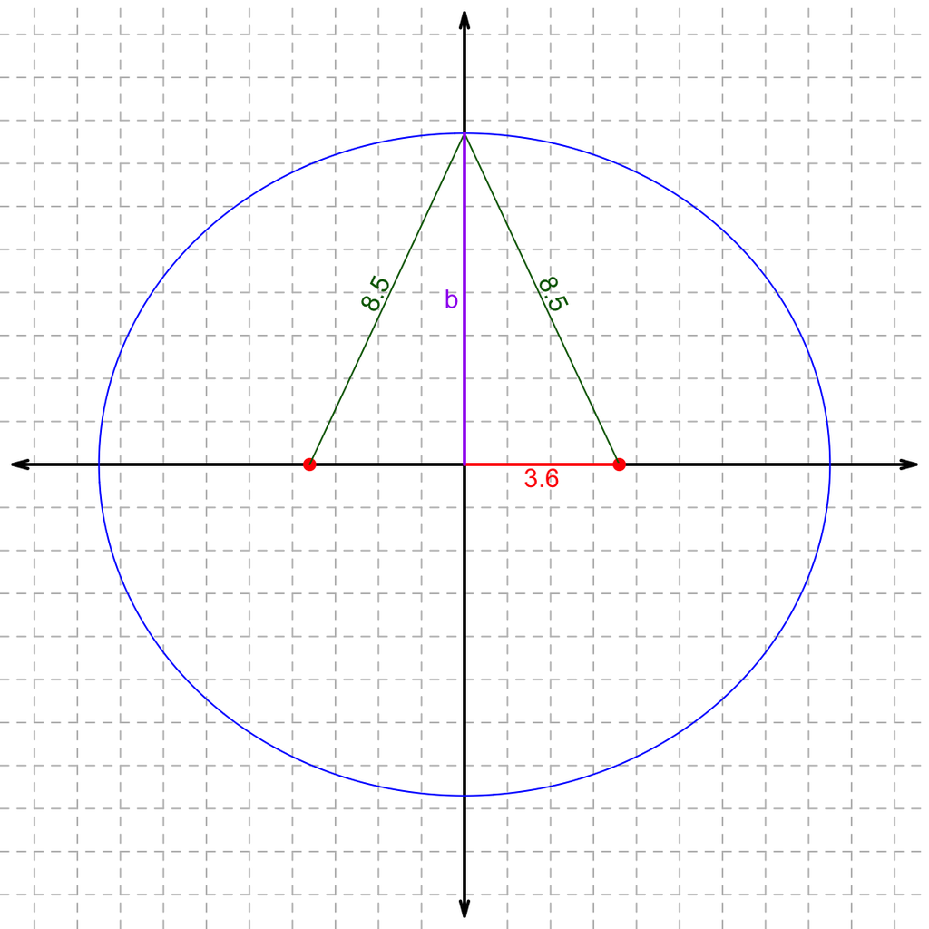

Notice the right triangle. We know two sides, and we are hoping to find the third side. Use [Pythagorean Equation](https://en.wikipedia.org/wiki/Pythagorean_theorem). However, notice that standard way of defining $a$ and $c$ in an ellipse does not match the standard way for defining $a$ and $c$ in Pythagorean Equation!

$$3.6^2+b^2=8.5^2$$

$$b^2=8.5^2-3.6^2$$

$$b^2=72.25-12.96$$

$$b^2=59.29$$

$$b=\sqrt{59.29}$$

$$b=7.7$$

The length of the minor axis is twice $b$.

$$2b=15.4$$

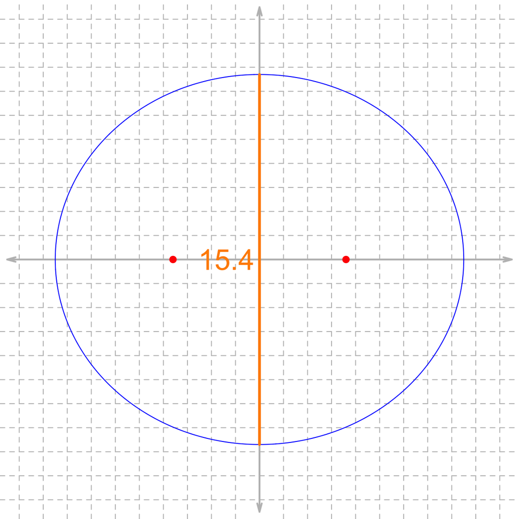

I should also mention that if $x^2+y^2=z^2$, then $(2x)^2+(2y)^2=(2z)^2$. This implies we can also get our answer without halving and doubling.

$$2b = \sqrt{(2a)^2-(2c)^2} =
\sqrt{17^2-7.2^2} = 15.4$$

# Meta-information

extype: num exsolution: 15.4 exname: pins_string_get_minor